# Modeling and Prediction for Movies

## Setup

### Load packages

```r
library(ggplot2)
library(dplyr)
library(statsr)
```

### Load data

This dataset was loaded using:

```r
load("../data/movies.Rdata")
```

## Part 1: Data

The file **‘movies.Rdata’** is used as a dataset for this analysis, which contains information about **movies**.

This dataset includes variables about movies such as:

- **‘genre’**: Type of the movies
- **‘imdb_rating’**: IMDB rating
- **‘audience_score’**: Average rating from audience (response variable)
- **‘runtime’**: Movie length (minutes)
- **‘director’**, **‘actor’**, **‘critics_score’**, and others

## Part 2: Research Question

Goal of this project is to investigate **what attributes make a movie popular**. Therefore, factors which are associated with the higher audience scores for movies are investigated.

**The Research Question**:

What characteristics of a movie such as genre, runtime, studio are associated with audience success (as measured by audience_score)?

I will perform **exploratory data analysis** followed by multiple linear regression modeling to label the question. Response variable of interest will be **‘audience_score’**.

## Part 3: Exploratory Data Analysis

Our analysis starts with exploring how the **audience_score** variable distributes across **different genres, run times, and studios**.

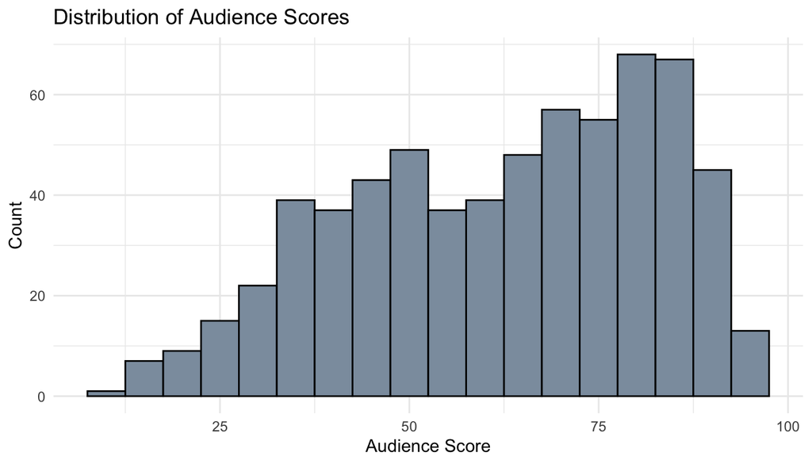

```r
ggplot(movies, aes(x = audience_score)) +
  geom_histogram(binwidth = 5, fill = "#8C9DAD", color = "black") +
  labs(title = "Distribution of Audience Scores",
       x = "Audience Score", y = "Count") +
  theme_minimal()
```

```r
ggsave("../images/hist_audience_score.png")
```

The histogram displays that audience scores are fairly **symmetrically distributed** or **slightly left-skewed**, with a peak around **80-90**.

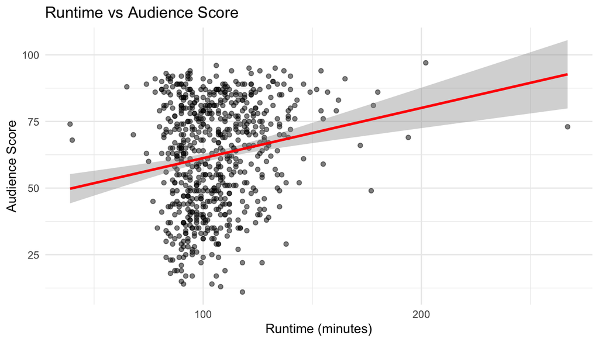

```r
ggplot(movies, aes(x = runtime, y = audience_score)) +
  geom_point(alpha = 0.5) +
  geom_smooth(method = "lm", color = "red") +
  labs(title = "Runtime vs Audience Score",
       x = "Runtime (minutes)", y = "Audience Score") +
  theme_minimal()
```

```r
ggsave("../images/scatter_runtime_audience.png")
```

On the other hand, on the **scatter plot**, there seems to be a **slight positive linear trend** between **run time** and **audience_score**.

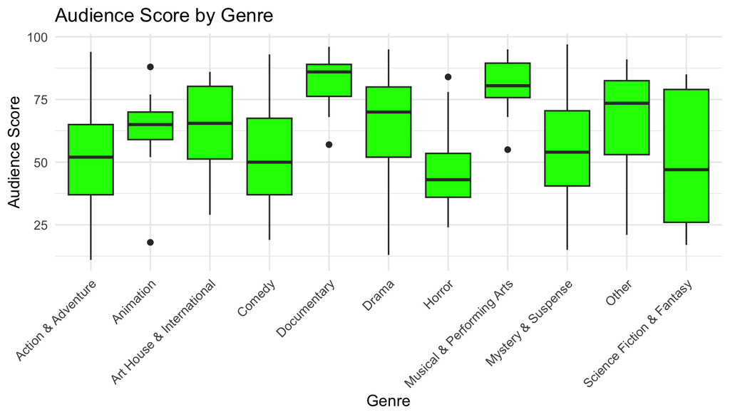

```r
ggplot(movies, aes(x = genre, y = audience_score)) +
  geom_boxplot(fill = "green") +
  labs(title = "Audience Score by Genre",
       x = "Genre", y = "Audience Score") +
  theme_minimal() +
  theme(axis.text.x = element_text(angle = 45, hjust = 1))
```

```r
ggsave("../images/boxplot_genre_audience.png")
```

Also, the **box plots** propose that certain genres such as **documentary and musical & performing arts** may be associated with **higher audience ratings** on average.

```r
top_studios <- movies %>%
  count(studio, sort = TRUE) %>%
  top_n(10) %>%
  pull(studio)
```

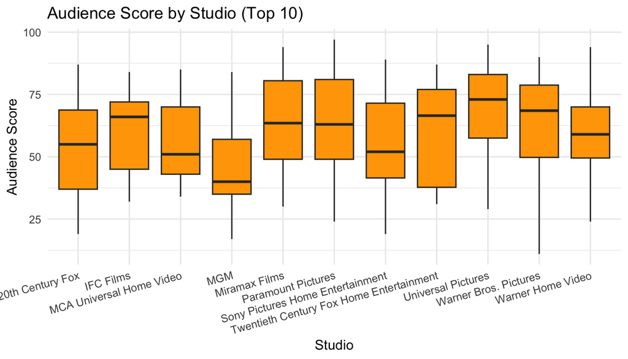

```r
movies_top_studios <- movies %>% filter(studio %in% top_studios)

ggplot(movies_top_studios, aes(x = studio, y = audience_score)) +
  geom_boxplot(fill = "orange") +
  labs(title = "Audience Score by Studio (Top 10)",
       x = "Studio", y = "Audience Score") +
  theme_minimal() +
  theme(axis.text.x = element_text(angle = 15, hjust = 1))
```

```r
ggsave("../images/boxplot_studio_audience.png")
```

Finally, **studios** also indicate variation in **audience scores** with considerable overlap and variability.

## Part 4: Modeling

```r
model <- lm(audience_score ~ runtime + imdb_rating + genre, data = movies)
summary(model)
```

```
##
## Call:
## lm(formula = audience_score ~ runtime + imdb_rating + genre,
##     data = movies)
##
## Residuals:
##     Min      1Q  Median      3Q     Max
## -27.404  -6.135   0.740   5.409  50.708
##
## Coefficients:
##                                 Estimate Std. Error t value Pr(>|t|)
## (Intercept)                    -38.54338    3.17207 -12.151  < 2e-16 ***
## runtime                         -0.04537    0.02193  -2.069  0.03896 *
## imdb_rating                     16.25199    0.41954  38.738  < 2e-16 ***
## genreAnimation                   9.05792    3.52529   2.569  0.01041 *
## genreArt House & International  -0.31822    2.91902  -0.109  0.91322
## genreComedy                      2.08204    1.62420   1.282  0.20035
## genreDocumentary                 1.53778    1.99560   0.771  0.44124
## genreDrama                       0.46079    1.37925   0.334  0.73842
## genreHorror                     -5.07663    2.40531  -2.111  0.03520 *
## genreMusical & Performing Arts   5.23078    3.14580   1.663  0.09685 .
## genreMystery & Suspense         -5.81702    1.78719  -3.255  0.00119 **
## genreOther                       2.50389    2.76651   0.905  0.36577
## genreScience Fiction & Fantasy   0.47490    3.50846   0.135  0.89237
## ---
## Signif. codes:  0 '***' 0.001 '**' 0.01 '*' 0.05 '.' 0.1 ' ' 1
##
## Residual standard error: 9.861 on 637 degrees of freedom
##   (1 observation deleted due to missingness)
## Multiple R-squared:  0.7669, Adjusted R-squared:  0.7625
## F-statistic: 174.6 on 12 and 637 DF,  p-value: < 2.2e-16
```

Multiple linear regression model is fitted to predict ‘audience score’ using ‘runtime’, ‘imdb_rating’, and ‘genre’ as explanatory variables.

### Model Summary:

- **Adjusted R-squared**: 0.7625 –> About **76% of the variation** in audience scores is explained by the model.
- **F-statistic**: Very significant (**p-value: < 2.2e-16**), indicating that the model as a whole is meaningful.

### Conclusion:

The model shows that **IMDB rating** is the strongest single predictor of audience score. While **runtime** is statistically significant (p = 0.03896) it has **a small negative effect**, genre seems to influence audience reception, especially in genres such as Animation and Horror.

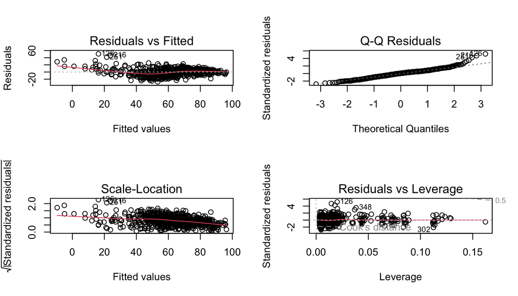

```r
par(mfrow = c(2, 2))
plot(model)
```

### Diagnostic Plot Comments:

Diagnostics plots are examined to assess whether the assumptions of linear regression were reasonably met.

- **Residuals vs Fitted**: The residuals show a random scattered pattern around zero while a slight curve can be seen at the low end of fitted values. Therefore, also assumption of linearity is **mostly satisfied**, there can be a mild non-linearity in lower range of fitted values.
- **Normal Q-Q Plot**: Residuals usually follow the straight line. However, at the upper line there are few points which deviates from the line. This shows that residuals seem like normally distributed with some mild deviation in the upper line.
- **Scale-Location Plot**: While the red line seems almost flat, there are some spread differences across lower fitted values. This suggests that *mostly constant variance* but also higher fitted values may be in lower variance.
- **Residuals vs Leverage**: Some data points such as 126 have higher leverage or residuals. However, none of them cross the Cook’s distance threshold. Thus, *no highly influential points* were found.

### Conclusion:

To sum up, the validity of the linear regression model is supported by the diagnostic plots. There are no influential outliers were detected that would prevent the model’s reliability. Therefore, the assumptions for linearity, normality, and homoscedasticity are provided.

## Part 5: Prediction

```r
real_movies <- data.frame(
  runtime = c(106, 118, 85),
  imdb_rating = c(7.9, 7.6, 7.5),
  genre = c("Drama", "Action & Adventure", "Animation")
)

predict(model, newdata = real_movies, interval = "prediction")
```

```
##        fit      lwr       upr
## 1 85.49945 66.07376 104.92513
## 2 79.61868 60.06143  99.17593
## 3 88.54845 68.09287 109.00402
```

To make a prediction about the audience scores of three real movies, the regression model is used and compared the predicted values with the actual Rotten Tomatoes audience scores. In this way, we can assess the real-world applicability of our model.

### Predictions for Real Movies

[output not shown]

### Interpretation

- Prediction of audience scores for all three movies are reasonably close to the actual values.
- All three actual scores which are 95 fall within the **95% prediction intervals**, showing that the model conducts good in capturing the range of possible outcomes.
- On the other hand, the model slightly **underpredicts** the actual audience scores, especially for high-performing films. Therefore, when modeling high-rated movies or “cult movies”, there should be a suggestion of limitation for the variables in the dataset.

This test of real-world movies prediction displays that our model is effective for the general audience score prediction yet knowing its limitations for forecasting extreme popular movies.

## Part 6: Conclusion

As a conclusion, attributes that are associated with a movie’s audience score are explored using linear regression in this project.

First of all, exploratory data analysis is made that suggests **runtime, studio, and genre** may be associated with audience scores. A slight positive linear trend between runtime and audience score seemed on the scatter plot. Also, the box plot clearly displayed higher average audience scores for genres such as Documentary and Musical & Performing Arts.

**R-squared value of 0.77** showed a strong overall model fit which indicates that the predictors explains the substantial portion of the variation in audience scores.

To test our regression model, we used the model to **predict the audience scores** of three real-world movies using their runtime, genre, and IMDB rating. While confidence interval and the range of the predicted audience scores were closely aligned with the real-world scores, there were **some limitations** for the higher rated movies.

To sum up, this analysis cleared how movie characteristics can be used to understand and predict audience behavior.